# Mini-Project 02

Making Backyards Affordable for All

Author

Caitlin Uang

Published

October 27, 2025

## Introduction and Background

## Data Acquisition

#### Household Demographic and Economic Indicators from American Community Survey (ACS)

```r
if(!dir.exists(file.path("data", "mp02"))){
    dir.create(file.path("data", "mp02"), showWarnings=FALSE, recursive=TRUE)
}

library <- function(pkg){
    ## Mask base::library() to automatically install packages if needed
    ## Masking is important here so downlit picks up packages and links
    ## to documentation
    pkg <- as.character(substitute(pkg))
    options(repos = c(CRAN = "https://cloud.r-project.org"))
    if(!require(pkg, character.only=TRUE, quietly=TRUE)) install.packages(pkg)
    stopifnot(require(pkg, character.only=TRUE, quietly=TRUE))
}

library(tidyverse)
library(glue)
library(readxl)
library(tidycensus)


get_acs_all_years <- function(variable, geography="cbsa",
                              start_year=2009, end_year=2023){
    fname <- glue("{variable}_{geography}_{start_year}_{end_year}.csv")
    fname <- file.path("data", "mp02", fname)

    if(!file.exists(fname)){
        YEARS <- seq(start_year, end_year)
        YEARS <- YEARS[YEARS != 2020] # Drop 2020 - No survey (covid)

        ALL_DATA <- map(YEARS, function(yy){
            tidycensus::get_acs(geography, variable, year=yy, survey="acs1") |>
                mutate(year=yy) |>
                select(-moe, -variable) |>
                rename(!!variable := estimate)
        }) |> bind_rows()

        write_csv(ALL_DATA, fname)
    }

    read_csv(fname, show_col_types=FALSE)
}

# Household income (12 month)
INCOME <- get_acs_all_years("B19013_001") |>
    rename(household_income = B19013_001)

# Monthly rent
RENT <- get_acs_all_years("B25064_001") |>
    rename(monthly_rent = B25064_001)

# Total population
POPULATION <- get_acs_all_years("B01003_001") |>
    rename(population = B01003_001)

# Total number of households
HOUSEHOLDS <- get_acs_all_years("B11001_001") |>
    rename(households = B11001_001)
```

#### Number of New Housing Unit Built Each Year

```r
# Number of new housing built each year
get_building_permits <- function(start_year = 2009, end_year = 2023){
    fname <- glue("housing_units_{start_year}_{end_year}.csv")
    fname <- file.path("data", "mp02", fname)

    if(!file.exists(fname)){
        HISTORICAL_YEARS <- seq(start_year, 2018)

        HISTORICAL_DATA <- map(HISTORICAL_YEARS, function(yy){
            historical_url <- glue("https://www.census.gov/construction/bps/txt/tb3u{yy}.txt")

            LINES <- readLines(historical_url)[-c(1:11)]

            CBSA_LINES <- str_detect(LINES, "^[[:digit:]]")
            CBSA <- as.integer(str_sub(LINES[CBSA_LINES], 5, 10))

            PERMIT_LINES <- str_detect(str_sub(LINES, 48, 53), "[[:digit:]]")
            PERMITS <- as.integer(str_sub(LINES[PERMIT_LINES], 48, 53))

            data_frame(CBSA = CBSA,
                       new_housing_units_permitted = PERMITS,
                       year = yy)
        }) |> bind_rows()

        CURRENT_YEARS <- seq(2019, end_year)

        CURRENT_DATA <- map(CURRENT_YEARS, function(yy){
            current_url <- glue("https://www.census.gov/construction/bps/xls/msaannual_{yy}99.xls")

            temp <- tempfile()

            download.file(current_url, destfile = temp, mode="wb")

            fallback <- function(.f1, .f2){
                function(...){
                    tryCatch(.f1(...),
                             error=function(e) .f2(...))
                }
            }

            reader <- fallback(read_xlsx, read_xls)

            reader(temp, skip=5) |>
                na.omit() |>
                select(CBSA, Total) |>
                mutate(year = yy) |>
                rename(new_housing_units_permitted = Total)
        }) |> bind_rows()

        ALL_DATA <- rbind(HISTORICAL_DATA, CURRENT_DATA)

        write_csv(ALL_DATA, fname)

    }

    read_csv(fname, show_col_types=FALSE)
}

PERMITS <- get_building_permits()
```

#### BLS Records Using the NAICS Coding System

```r
library(httr2)
library(rvest)
get_bls_industry_codes <- function(){
    fname <- file.path("data", "mp02", "bls_industry_codes.csv")
    library(dplyr)
    library(tidyr)
    library(readr)

    if(!file.exists(fname)){

        resp <- request("https://www.bls.gov") |>
            req_url_path("cew", "classifications", "industry", "industry-titles.htm") |>
            req_headers(`User-Agent` = "Mozilla/5.0 (Macintosh; Intel Mac OS X 10.15; rv:143.0) Gecko/20100101 Firefox/143.0") |>
            req_error(is_error = \(resp) FALSE) |>
            req_perform()

        resp_check_status(resp)

        naics_table <- resp_body_html(resp) |>
            html_element("#naics_titles") |>
            html_table() |>
            mutate(title = str_trim(str_remove(str_remove(`Industry Title`, Code), "NAICS"))) |>
            select(-`Industry Title`) |>
            mutate(depth = if_else(nchar(Code) <= 5, nchar(Code) - 1, NA)) |>
            filter(!is.na(depth))

        # These were looked up manually on bls.gov after finding
        # they were presented as ranges. Since there are only three
        # it was easier to manually handle than to special-case everything else
        naics_missing <- tibble::tribble(
            ~Code, ~title, ~depth,
            "31", "Manufacturing", 1,
            "32", "Manufacturing", 1,
            "33", "Manufacturing", 1,
            "44", "Retail", 1,
            "45", "Retail", 1,
            "48", "Transportation and Warehousing", 1,
            "49", "Transportation and Warehousing", 1
        )

        naics_table <- bind_rows(naics_table, naics_missing)

        naics_table <- naics_table |>
            filter(depth == 4) |>
            rename(level4_title=title) |>
            mutate(level1_code = str_sub(Code, end=2),
                   level2_code = str_sub(Code, end=3),
                   level3_code = str_sub(Code, end=4)) |>
            left_join(naics_table, join_by(level1_code == Code)) |>
            rename(level1_title=title) |>
            left_join(naics_table, join_by(level2_code == Code)) |>
            rename(level2_title=title) |>
            left_join(naics_table, join_by(level3_code == Code)) |>
            rename(level3_title=title) |>
            select(-starts_with("depth")) |>
            rename(level4_code = Code) |>
            select(level1_title, level2_title, level3_title, level4_title,
                   level1_code,  level2_code,  level3_code,  level4_code) |>
            drop_na() |>
            mutate(across(contains("code"), as.integer))

        write_csv(naics_table, fname)
    }

    read_csv(fname, show_col_types=FALSE)
}

INDUSTRY_CODES <- get_bls_industry_codes()
```

#### BLS Quarterly Census of Employment and Wages

```r
library(httr2)
library(rvest)
get_bls_qcew_annual_averages <- function(start_year=2009, end_year=2023){
    fname <- glue("bls_qcew_{start_year}_{end_year}.csv.gz")
    fname <- file.path("data", "mp02", fname)

    YEARS <- seq(start_year, end_year)
    YEARS <- YEARS[YEARS != 2020] # Drop Covid year to match ACS

    if(!file.exists(fname)){
        ALL_DATA <- map(YEARS, .progress=TRUE, possibly(function(yy){
            fname_inner <- file.path("data", "mp02", glue("{yy}_qcew_annual_singlefile.zip"))

            if(!file.exists(fname_inner)){
                request("https://www.bls.gov") |>
                    req_url_path("cew", "data", "files", yy, "csv",
                                 glue("{yy}_annual_singlefile.zip")) |>
                    req_headers(`User-Agent` = "Mozilla/5.0 (Macintosh; Intel Mac OS X 10.15; rv:143.0) Gecko/20100101 Firefox/143.0") |>
                    req_retry(max_tries=5) |>
                    req_perform(fname_inner)
            }

            if(file.info(fname_inner)$size < 755e5){
                warning(sQuote(fname_inner), "appears corrupted. Please delete and retry this step.")
            }

            read_csv(fname_inner,
                     show_col_types=FALSE) |>
                mutate(YEAR = yy) |>
                select(area_fips,
                       industry_code,
                       annual_avg_emplvl,
                       total_annual_wages,
                       YEAR) |>
                filter(nchar(industry_code) <= 5,
                       str_starts(area_fips, "C")) |>
                filter(str_detect(industry_code, "-", negate=TRUE)) |>
                mutate(FIPS = area_fips,
                       INDUSTRY = as.integer(industry_code),
                       EMPLOYMENT = as.integer(annual_avg_emplvl),
                       TOTAL_WAGES = total_annual_wages) |>
                select(-area_fips,
                       -industry_code,
                       -annual_avg_emplvl,
                       -total_annual_wages) |>
                # 10 is a special value: "all industries" , so omit
                filter(INDUSTRY != 10) |>
                mutate(AVG_WAGE = TOTAL_WAGES / EMPLOYMENT)
        })) |> bind_rows()

        write_csv(ALL_DATA, fname)
    }

    ALL_DATA <- read_csv(fname, show_col_types=FALSE)

    ALL_DATA_YEARS <- unique(ALL_DATA$YEAR)

    YEARS_DIFF <- setdiff(YEARS, ALL_DATA_YEARS)

    if(length(YEARS_DIFF) > 0){
        stop("Download failed for the following years: ", YEARS_DIFF,
             ". Please delete intermediate files and try again.")
    }

    ALL_DATA
}

WAGES <- get_bls_qcew_annual_averages()
```

## Data Integration and Initial Exploration

### Multi-Table Questions

#### 1. Which CBSA (by name) permitted the largest number of new housing units in the decade from 2010 to 2019 (inclusive)?

```r
# CBSA by name permitted largest number of new housing unit 2010-2019
top_CBSA <- PERMITS |>
  filter(between(year, 2010, 2019)) |>
  group_by(CBSA) |>
  summarize(total_permits = sum(new_housing_units_permitted, na.rm = TRUE), .groups = "drop") |>
  arrange(desc(total_permits)) |>
  rename(`Total Permits (2010-2019)` = total_permits) |>
  left_join(INCOME |> select(GEOID, NAME) |> distinct(), join_by(CBSA == GEOID))

# Create an interactive datatable
library(DT)
datatable(top_CBSA)
```

|  | CBSA | Total Permits (2010-2019) | NAME |
| --- | --- | --- | --- |
| 1 | 26420 | 482075 | Houston-Sugar Land-Baytown, TX Metro Area |
| 2 | 26420 | 482075 | Houston-The Woodlands-Sugar Land, TX Metro Area |
| 3 | 26420 | 482075 | Houston-Pasadena-The Woodlands, TX Metro Area |
| 4 | 19100 | 460826 | Dallas-Fort Worth-Arlington, TX Metro Area |
| 5 | 35620 | 446020 | New York-Northern New Jersey-Long Island, NY-NJ-PA Metro Area |
| 6 | 35620 | 446020 | New York-Newark-Jersey City, NY-NJ-PA Metro Area |
| 7 | 35620 | 446020 | New York-Newark-Jersey City, NY-NJ Metro Area |
| 8 | 12060 | 254377 | Atlanta-Sandy Springs-Marietta, GA Metro Area |
| 9 | 12060 | 254377 | Atlanta-Sandy Springs-Roswell, GA Metro Area |
| 10 | 12060 | 254377 | Atlanta-Sandy Springs-Alpharetta, GA Metro Area |

[output cut: 545 more lines]

[output not shown]

[output cut: 545 more lines]

The CSBA (by name) that permitted the largest number of new housing units from 2010 to 2019 is **CSBA code 26420** known as the **Houston-Sugar Land-Baytown, TX Metro Area, at 482,075 permits**.

#### 2. In what year did Albuquerque, NM (CBSA Number 10740) permit the most new housing units?

```r
nm_permit <- PERMITS |>
  filter(CBSA == 10740) |>
  group_by(year) |>
  summarize(total_permits = sum(new_housing_units_permitted, na.rm = TRUE), .groups = "drop") |>
  arrange(desc(total_permits)) |>
  slice_head(n = 1)
```

Albuquerque, NM (CBSA number 10740) permitted the most new housing units in **2021**, with **4021** units.

#### 3. Which state (not CBSA) had the highest average individual income in 2015?

```r
library(dplyr)
library(stringr)
library(tibble)

# extracting state abbreviation from CBSA name
extract_state <- function(name) {
  str_extract(name, "(?<=, )[A-Z]{2}")
}

# define state abbreviation to full state name
state_df <- data.frame(abb  = c(state.abb, "DC", "PR"),
                       name = c(state.name, "District of Columbia", "Puerto Rico"))

# total income in 2015
base_total <- INCOME |>
  filter(year == 2015) |>
  left_join(HOUSEHOLDS |> filter(year == 2015), by = c("GEOID","NAME","year")) |>
  left_join(POPULATION |> filter(year == 2015), by = c("GEOID","NAME","year")) |>
  mutate(
    state = extract_state(NAME),
    total_income = household_income * households
  )

# aggregate to state level to compute average individual income
high_income <- base_total |>
  group_by(state) |>
  summarise(
    total_income = sum(total_income, na.rm = TRUE),
    total_population = sum(population, na.rm = TRUE),
    .groups = "drop"
  ) |>
  mutate(avg_income = total_income / total_population) |>
  arrange(desc(avg_income)) |>
  left_join(state_df, by = c("state" = "abb")) |>
  slice_head(n = 1)
```

In 2015, the state with highest individual income was **DC** with an average income of $33,233.

### Initial Visualizations

#### The relationship between monthly rent and average household income per CBSA in 2009.

Households with higher average household income are typically associated with higher monthly rent across different CSBAs. As seen with this visualization, wealthier households live in a more expensive housing area.

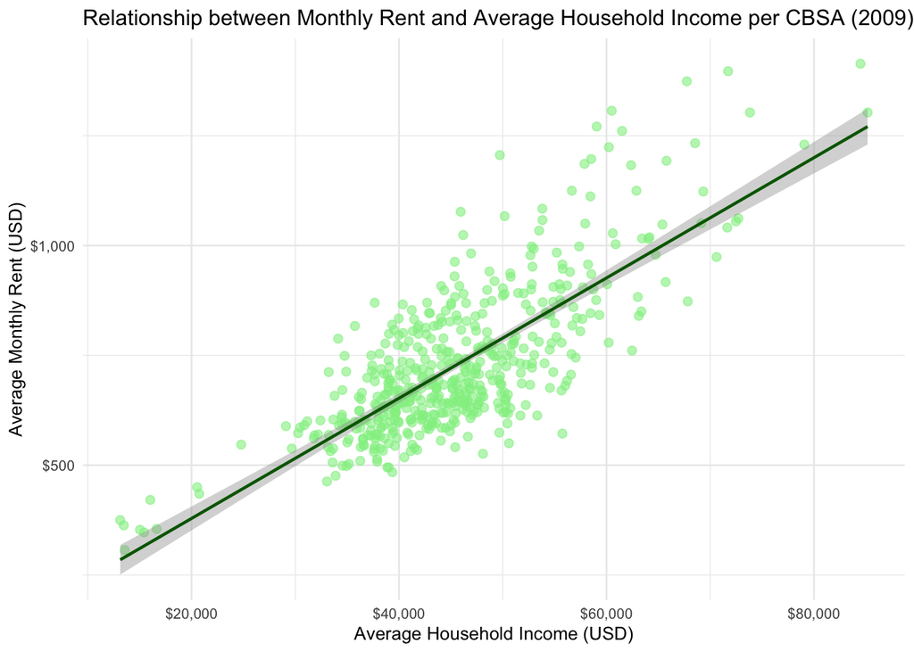

```r
library(dplyr)
library(ggplot2)
library(scales)

# Merge rent and income data for 2009
rent_income_2009 <- RENT |>
  filter(year == 2009) |>
  left_join(INCOME |> filter(year == 2009), by = c("GEOID", "NAME", "year")) |>
  drop_na(monthly_rent, household_income)

# create scatterplot
ggplot(rent_income_2009, aes(x = household_income, y = monthly_rent)) +
  geom_point(alpha = 0.6, size = 2, color = "lightgreen") +
  geom_smooth(method = "lm", se = TRUE, color = "darkgreen", linewidth = 0.8) +
  scale_x_continuous(labels = label_dollar()) +
  scale_y_continuous(labels = label_dollar()) +
  labs(
    title = "Relationship between Monthly Rent and Average Household Income per CBSA (2009)",
    x = "Average Household Income (USD)",
    y = "Average Monthly Rent (USD)"
  ) +
  theme_minimal(base_size = 10)
```

#### The relationship between total employment and total employment in the health care and social services sector (NAICS 62) across different CBSAs.

A strong positive relationship is observed between total employment and the employment in the health care and social service sector across CBSAs. This can indicate that the larger the labor market , the greater amount of workers there are in this sector.

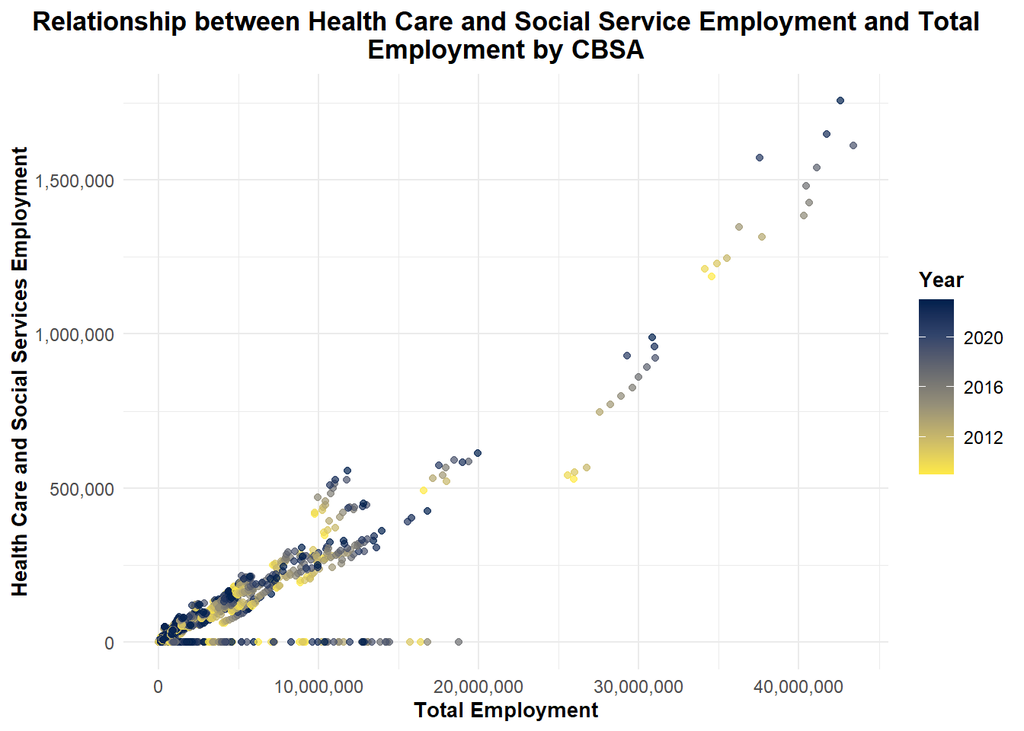

```r
# Filter healthcare sector and summarize by year
healthcare <- WAGES |>
  filter(INDUSTRY == 62) |>
  group_by(FIPS, YEAR) |>
  summarize(healthcare_employment = sum(EMPLOYMENT, na.rm = TRUE), .groups = "drop")

# Summarize total employment
total <- WAGES |>
  group_by(FIPS, YEAR) |>
  summarize(total_employment = sum(EMPLOYMENT, na.rm = TRUE), .groups = "drop")

# Combine and calculate share
healthcare_total <- total |>
  left_join(healthcare, by = c("FIPS", "YEAR")) |>
  mutate(health_share = healthcare_employment / total_employment)

# Plotting
ggplot(healthcare_total, aes(x = total_employment, y = healthcare_employment, color = YEAR)) +
  geom_point(alpha = 0.7) +
  scale_x_continuous(labels = comma) +
  scale_y_continuous(labels = comma) +
  scale_color_viridis_c(option = "cividis", direction = -1) +
  labs(
    title = str_wrap("Relationship between Health Care and Social Service Employment and Total Employment by CBSA"),
    x = "Total Employment",
    y = "Health Care and Social Services Employment",
    color = "Year",
  ) +
  theme_minimal(base_size = 10) +
  theme(
    plot.title = element_text(face = "bold", size = 13, hjust = 0.5),
    plot.subtitle = element_text(size = 10, hjust = 0.5, color = "green"),
    axis.title = element_text(size = 10, face = "bold"),
    axis.text = element_text(size = 9),
    legend.title = element_text(size = 10, face = "bold"),
    legend.text = element_text(size = 9)
  )
```

```r
# create table combining POPULATION and HOUSEHOLDS
glimpse(HOUSEHOLDS)
```

```
Rows: 7,279
Columns: 4
$ GEOID      <dbl> 10140, 10180, 10300, 10380, 10420, 10500, 10540, 10580, 107…
$ NAME       <chr> "Aberdeen, WA Micro Area", "Abilene, TX Metro Area", "Adria…
$ households <dbl> 27759, 58052, 36835, 91805, 281769, 60101, 43953, 336492, 3…
$ year       <dbl> 2009, 2009, 2009, 2009, 2009, 2009, 2009, 2009, 2009, 2009,…
```

```r
glimpse(POPULATION)
```

```
Rows: 7,279
Columns: 4
$ GEOID      <dbl> 10140, 10180, 10300, 10380, 10420, 10500, 10540, 10580, 107…
$ NAME       <chr> "Aberdeen, WA Micro Area", "Abilene, TX Metro Area", "Adria…
$ population <dbl> 71797, 160266, 99837, 342495, 699935, 164238, 116584, 85759…
$ year       <dbl> 2009, 2009, 2009, 2009, 2009, 2009, 2009, 2009, 2009, 2009,…
```

## Building Indices of Housing Affordability and Housing Stock

### Rent Burden

### Housing Growth

### Visualization

## Policy Brief